# Homework 2 (9-8-25)

## [1.2] 1a, 1c, 2b, 3b, 4, 5, 6, 7

## [1.3] 1, 2, 3, 4, 5, 6

## **Section 1.2**

### Question 1a

Recall, $\kappa_f(x) = \big|\frac{xf'(x)}{f(x)}\big|$. Then, for $f(x) = x^p$, we get: $\kappa_f(x) = \big|\frac{x(px^{p - 1})}{x^p}\big| = \boxed{p}$.

### Question 1c

For $f(x) = \cos(x)$, we get $\kappa_f(x) = |\frac{x(-\sin x)}{\cos x}| = \boxed{x \tan x}$

### Question 2b

#### **Chain Rule:**

Recall, for $h(x) = f(g(x))$, the chain rule states $\kappa_h(x) = \kappa_f(g(x)) \cdot \kappa_g(x)$

So, for $f(x) = \cos(2\pi x)$, set $g(x) = 2\pi x$ and $\ell(x) = \cos(x)$, so that $f(x) = \ell(g(x))$. Then, $\kappa_f(x) = \kappa_\ell(2 \pi x) \cdot (1) = \boxed{2 \pi x \tan(2 \pi x)}$

#### **By (1.2.6):**

By $\kappa_f(x) = |\frac{xf'(x)}{f(x)}|$, we get $\kappa_f(x) = |\frac{-2\pi x \sin(2\pi x)}{\cos(2\pi x)}| = \boxed{2 \pi x \tan(2 \pi x)}$.

### Question 3b

First, we consider evaluating the condition number,

For $f(x) = \frac{e^x - 1}{x}$, we notice $f'(x) = \frac{xe^x - (e^x - 1)}{x^2}$.

By $\kappa_f(x) = |\frac{xf'(x)}{f(x)}|$, we get $\kappa_f(x) = |(\frac{xe^x - (e^x - 1)}{x}) \cdot (\frac{x}{e^x - 1})| = |\frac{xe^x}{e^x - 1} - 1|$.

Now, we consider what values of $x$ cause $\kappa_f(x) \to \infty$.

We notice, $\kappa_f(x) \to \infty$ when $|\frac{xe^x}{e^x - 1}| \to \infty$. When the denominator equals $0$ (and hence limit $\to \infty$), we have $e^x - 1 = 0 \Rightarrow x = 0$. Otherwise, as $x \to \infty$, then $|\frac{xe^x}{e^x - 1}| = |x + \frac{x}{e^x - 1}| \to \infty$. As $x \to -\infty$, by L'Hopital's Rule, $\lim_{x \to -\infty}|\frac{xe^x}{e^x - 1}| = \lim_{x \to -\infty}|\frac{e^x(x + 1)}{e^x}| = \infty$.

Hence, in conclusion, the condition number of $f(x)$ approaches $\infty$ when $\boxed{x = 0, x \to \pm \infty}$.

### Question 4

Recall, (1.2.9) states $\kappa_h(x) = \kappa_f(g(x)) \cdot \kappa_g(x)$. To prove this, we go back to (1.2.6).

Notice, $\kappa_h(x) = |\frac{xh'(x)}{h(x)}| = |\frac{xf'(g(x)) g'(x)}{f(g(x))}| = |\frac{g(x)f'(g(x))}{f(g(x))}| \cdot |\frac{xg'(x)}{g(x)}| = \boxed{\kappa_f(g(x)) \cdot \kappa_g(x)}$.

Hence, we proved (1.2.9) holds true.

### Question 5

Recall, $\kappa_f(x) = |\frac{xf'(x)}{f(x)}|$.

Thus, $\kappa_{f^{-1}}(x) = \left|\frac{x(f^{-1})'(x)}{f^{-1}(x)}\right| = \left|\frac{x}{f^{-1}(x) \cdot f'(f^{-1}(x))}\right| = \left(\left|\frac{f^{-1}(x) \cdot f'(f^{-1}(x))}{f(f^{-1}(x))}\right|\right)^{-1} = \boxed{\frac{1}{\kappa_f(f^{-1}(x))}}$

### Question 6

WLOG, we pick one root called $r$, where $f(b) = r$.

By using implicit differentiation w.r.t. $b$, we get $ar^2 + br + c = 0 \Rightarrow 2ar (\frac{dr}{db}) + b\frac{dr}{db} + r = 0 \Rightarrow \frac{dr}{db} = -\frac{r}{2ar + b}$

Hence, the condition number for the problem $f(b) = r$ is $\kappa(b) = |\frac{b}{r} \cdot \frac{dr}{db}| = |\frac{b}{2ar + b}|$.

By substiuting $r = \frac{-b \pm \sqrt{b^2 - 4ac}}{2a}$, we get $\kappa(b) = |\frac{b}{\sqrt{b^2 - 4ac}}|$.

Now, notice the roots of the original polynomial ($r_+$ and $r_-$) satisfy:

- $r_+ + r_- = -\frac{b}{a}$
- $r_+ - r_-$ = $\frac{\sqrt{b^2 - 4ac}}{a}$

Thus, $\kappa(b) = \boxed{\left|\frac{r_+ + r_-}{r_+ - r_-}\right|}$

### Question 7

#### Part (a)

```python
# The code for (1.2.7a)
import math

def solve_quad(a, b, c):
    return [(-b + math.sqrt(b ** 2 - 4 * a * c)) / (2 * a), (-b - math.sqrt(b ** 2 - 4 * a * c)) / (2 * a)]

for epsilon in [math.pow(10, -4), math.pow(10, -6), math.pow(10, -8), math.pow(10, -10), math.pow(10, -12)]:
    print(f"Epsilon = {epsilon}: {solve_quad(1, 2 + epsilon, 1)}")
```

```
Epsilon = 0.0001: [-0.9900498750007716, -1.0100501249992286]
Epsilon = 1e-06: [-0.9990004998749191, -1.001000500125081]
Epsilon = 1e-08: [-0.9999000050003038, -1.0001000049996962]
Epsilon = 1e-10: [-0.9999900000495863, -1.0000100000504137]
Epsilon = 1e-12: [-0.9999989999560508, -1.0000010000449493]
```

#### Part (b)

Take $\epsilon = 10^{-8}$ for example. Here, $\Delta r \approx 10^{-4}$.

The root value is supposed to be $-1$, so the relative root change is approximately $\frac{10^{-4}}{1} = 10^{-4}$. However, the relative coefficient change is roughly $\frac{10^{-8}}{2 + 10^{-8}} \approx 5 \times 10^{-9}$.

This means, the condition number is approximately $\frac{10^{-4}}{5 \times 10^{-9}} = \boxed{2 \times 10^4}$, meaning the condition number is $\boxed{\text{large}}$.

## **Section 1.3**

### Question 1

```python
# The code for (1.3.1)
# Write a function polyad for two polynomials p and q specified as vectors of coefficients in **decreasing** degree

# Polyadd
def polyadd(p, q):
    # Make sure deg p > deg q
    if len(p) < len(q):
        copy = p
        p = q
        q = copy

    # Iterate
    ans = []

    for i in range(len(p), 0, -1):
        ans = ans + [p[len(p) - i] + (0 if i > len(q) else q[len(q) - i])]

    return ans

# Test polyadd()
print(polyadd([1, 2], [4, 0, 9])) # (x + 2) + (4x^2 + 0x + 9) = 4x^2 + x + 11, and we do get [11, 1, 4]
```

```
[4, 1, 11]
```

### Question 2

```python
# The code for (1.3.2)
# Takes an input x of any length and returns variance (s^2)

import numpy as np

# Samplevar
def samplevar(x):
    n = len(x)
    if (n <= 1):
        print("Invalid length of x.")
        return

    x_bar = sum(x) / n
    s2 = sum((x_i - x_bar) ** 2 for x_i in x) / (n - 1)

    return s2

# Test samplevar() against np
data = [2, 0, 2, 5, 0, 9, 0, 8]

my_s2 = samplevar(data)
np_s2 = np.var(data, ddof=1)

print(f"My variance: {my_s2}; NumPy variance: {np_s2}")
```

```
My variance: 13.357142857142858; NumPy variance: 13.357142857142858
```

### Question 3

```python
# The code for (1.3.3)

import math

# Polyarea
def polyarea(x, y):
    n = len(x)

    # Append n + 1 so it's less annoying
    x.append(x[0])
    y.append(y[0])

    return abs(sum([x[k] * y[k + 1] - x[k + 1] * y[k] for k in range (n)])) / 2

# Test polyarea() (coords in counterclockwise order)
print(f"Area of (5, 10), (10, 10), (10, 15), (5, 15) = {polyarea([5, 10, 10, 5], [10, 10, 15, 15])}")

print(f"Area of (1, 0), (3, 0), (2, sqrt 3) = {polyarea([1, 3, 3], [0, 0, math.sqrt(3)])}")
```

```
Area of (5, 10), (10, 10), (10, 15), (5, 15) = 25.0
Area of (1, 0), (3, 0), (2, sqrt 3) = 1.7320508075688774
```

### Question 4

#### Part (a)

Recall, the relative condition number for $f(x)$ can be determined using $\kappa_f(x) = \left|\frac{xf'(x)}{f(x)}\right|$.

Substituting $f(x) = \frac{1 - \cos x}{\sin x}$, with $f'(x) = \frac{(\sin x)(\sin x) - (1 - \cos x)(\cos x)}{\sin^2 x} = \frac{1 - \cos x}{\sin^2 x} = \frac{f(x)}{x}$ $\kappa_f(x) = \left|\frac{xf'(x)}{f(x)}\right| = \boxed{1}$

#### Part (b)

As the relative condition number for $f(x)$ at $x = 10^{-6}$ is $1$, thus the absolute condition number is $10^{-6} (1) = 10 ^{-6}$. Hence, approximately $\boxed{6}$ digits will be lost to cancellation when computing $f$ directly for $x = 10^{-6}$.

#### Part (c)

Note, "poorly conditioned steps" refers to steps with a large condition number.

We know $\kappa_{x/2} (x) = 1$, and $\kappa_{\sin x}(x) = \left|\frac{x}{\tan x}\right|$, which is small for $|x| < 1$. Moreover, $\kappa_{\sin^2{x/2}}(x) = \left|\frac{x}{\tan(x/2)}\right|$, again it is small for $|x| < 1$.

Hence, the formula contains no poorly conditioned steps for $|x| < 1$.

#### Part (d)

```python
# This is the code for (1.3.4d)
import math

x = pow(10, -6)

print(f"Using (a), we get: {(1 - math.cos(x)) / (math.sin(x))}")
print(f"Using (c), we get: {(2 * (math.sin(x / 2)) ** 2) / (math.sin(x))}")
```

```
Using (a), we get: 5.000444502912538e-07
Using (c), we get: 5.000000000000416e-07
```

From the code, we see:

- Using (a), we get: `5.000444502912538e-07`
- Using (c), we get: `5.000000000000416e-07`

Noticably, (c) is $\boxed{\text{more accurate}}$ than (a) due to its lower condition number.

### Question 5

#### Part (a)

We see $f(x) = \frac{e^x - 1}{x}$, so $f'(x) = \frac{xe^x - (e^x - 1)}{x^2}$. Notice, $xf'(x) = e^x - f(x)$.

Hence, $\kappa_f(x) = \left|\frac{xf'(x)}{f(x)}\right| = \left|1 - \frac{xe^x}{e^x - 1}\right| = \left|(1 - x) - \frac{x}{e^x - 1}\right|$

Notice, over $-1 \leq x \leq 1$, we have $e^x - 1 \geq x$, which implies monoticity of $e^x - 1$, and moreover, $\frac{x}{e^x - 1} \leq 1$. Hence, the maximum value of $\kappa_f(x)$ must occur at the **endpoints** of the range $[-1, 1]$.

Notice,

- $\kappa_f(-1) = \left|(1 - (-1)) - \frac{-1}{e^{-1} - 1}\right| = \left|2 + \frac{e}{1 - e}\right| = \frac{e - 2}{e - 1}$
- $\kappa_f(1) = \left|(1 - 1) - \frac{1}{e^1 - 1}\right| = \frac{1}{e - 1}$

Notice, $\kappa_f(-1) < \kappa_f(1)$.

Hence, the maximum of $\kappa_f(x)$ is at $x = 1$, yielding $\boxed{\frac{1}{e - 1}}$.

#### Part (b) - (d)

[output not shown]

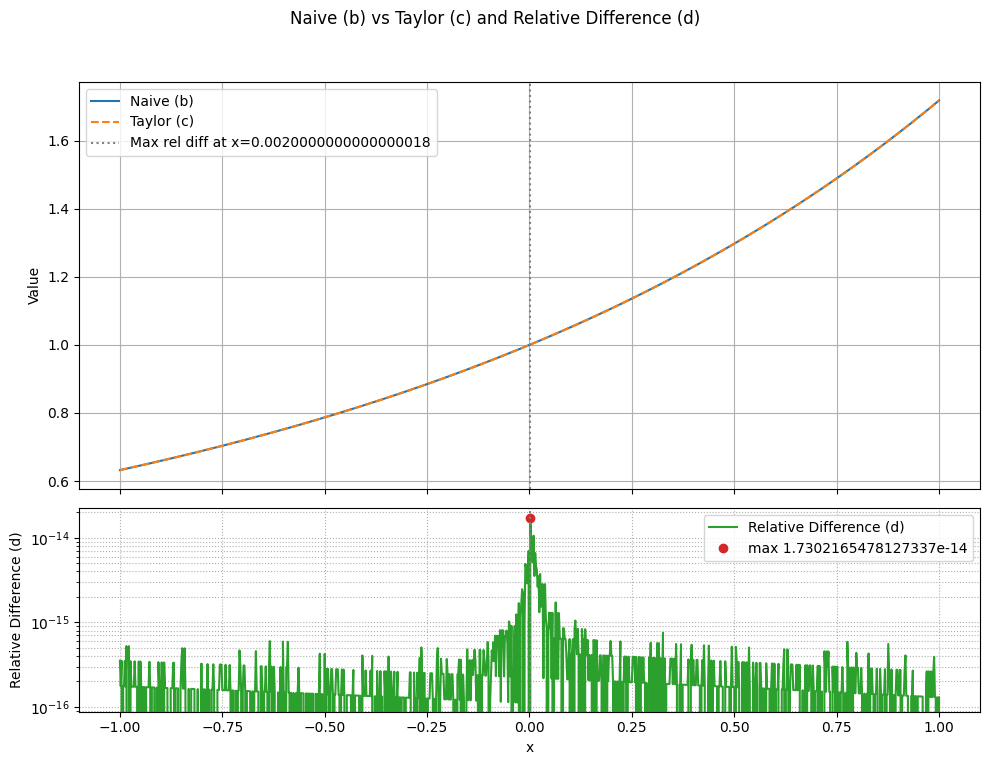

```python
# This is the code for (1.3.5b - 1.3.5d)
import math
import numpy as np
import matplotlib.pyplot as plt

def naive(x):
    if x == 0:
        return 1.0
    return (math.exp(x) - 1) / x

def taylor(x):
    factorial = 1
    ans = 1

    for i in range(2, 18, 1):
        factorial *= i
        ans += 1 / factorial * (x ** (i - 1))

    return ans

# X grid (avoid exact division-by-zero issues by handling x==0 separately)
x_vals = np.linspace(-1.0, 1.0, 1001)
naive_vals = np.array([naive(x) for x in x_vals])
taylor_vals = np.array([taylor(x) for x in x_vals]) # taylor(0) == 1.0 already

# Relative difference: |naive - taylor| / |naive| (safe-guard division by zero)
eps = 1e-16
rel_diff = np.abs(naive_vals - taylor_vals) / (np.abs(naive_vals) + eps)

imax = np.argmax(rel_diff)
x_max = x_vals[imax]
rel_max = rel_diff[imax]
print(f"Max relative difference at x = {x_max}, Relative difference = {rel_max}")
print(f"Naive = {naive_vals[imax]}, Taylor = {taylor_vals[imax]}")

# Plot: top = functions, bottom = relative difference (log scale) with marker
fig, (ax1, ax2) = plt.subplots(2, 1, figsize=(10, 8), sharex=True,
                               gridspec_kw={'height_ratios':[2,1]})

ax1.plot(x_vals, naive_vals, label='Naive (b)', color='C0')
ax1.plot(x_vals, taylor_vals, label='Taylor (c)', color='C1', linestyle='--')
ax1.axvline(x_max, color='gray', linestyle=':', label=f'Max rel diff at x={x_max}')
ax1.set_ylabel('Value')
ax1.legend()
ax1.grid(True)

ax2.semilogy(x_vals, rel_diff, label='Relative Difference (d)', color='C2')
ax2.plot(x_max, rel_max, 'o', color='C3', label=f'max {rel_max}')
ax2.axvline(x_max, color='gray', linestyle=':')
ax2.set_xlabel('x')
ax2.set_ylabel('Relative Difference (d)')
ax2.legend()
ax2.grid(True, which='both', ls=':')

plt.suptitle('Naive (b) vs Taylor (c) and Relative Difference (d)')
plt.tight_layout(rect=[0, 0.03, 1, 0.95])
plt.show()
```

Near the $|x| = 0$ part of the graph, we notice a higher relative difference (roughly $10^{-14}$ instead of $10^{-16}$) between the values. This is because the Taylor series is designed to accomodate these smaller values and be more accurate expanded around $x = 0$, whereas the naive algorithm is not. Hence, the Taylor series expansion is more accurate.

### Question 6

#### Part (a)

When $f(x) = \cosh^{-1}(x) = \log(x - \sqrt{x^2 - 1})$, note that $f'(x) = \frac{1}{\sqrt{x^2 - 1}}$.

Hence, to find the condition number, we can do the following: $\kappa_f(x) = \left|\frac{xf'(x)}{f(x)}\right| = \left|\frac{x}{\sqrt{x^2 - 1} \log(x - \sqrt{x^2 - 1})}\right|$

```python
# This is the code for (1.3.6a)
# Note that t = -4:-4:-16 is the same as range(-4, -17, -4)

import math

def kappa(x):
    return abs((x / math.sqrt(x ** 2 - 1) * math.log(x - math.sqrt(x ** 2 - 1))))

for t in range(-4, -17, -4):
    print(f"kappa_f({t}) = {kappa(math.cosh(t))}")
```

```
kappa_f(-4) = 4.002684601606776
kappa_f(-8) = 8.000001800734088
kappa_f(-12) = 12.000000137978219
kappa_f(-16) = 15.998624871202024
```

We know $\kappa_f(x) = \frac{\Delta f / f}{\Delta x / x}$. Notice, here, $\Delta x / x \approx 10^{-16}$. This means, $\Delta f \approx f \times 10^{-16}$. From the values calculated above, we conclude this problem is $\boxed{\text{well conditioned}}$ at these inputs.

#### Part (b)

```python
# This is the code for (1.3.6b)
import math

def acosh(x):
    return math.log(x - math.sqrt(x ** 2 - 1))

for t in range(-4, -17, -4):
    ans = acosh(math.cosh(t))
    print(f"For t = {t}, the backwards estimate is {ans}, with relative error {(t - ans) / t}")
```

```
For t = -4, the backwards estimate is -4.000000000000046, with relative error -1.1546319456101628e-14
For t = -8, the backwards estimate is -8.00000000017109, with relative error -2.138622612335439e-11
For t = -12, the backwards estimate is -12.000000137072186, with relative error -1.1422682207514375e-08
For t = -16, the backwards estimate is -15.998624871201619, with relative error 8.594554989882486e-05
```

Remark, the backwards estimate gets progressively less and less accurate.

#### Part (c)

```python
# This is the code for (1.3.6b)
import math

def acosh_alt(x):
    return -2 * math.log(math.sqrt((x + 1) / 2) + math.sqrt((x - 1) / 2))

for t in range(-4, -17, -4):
    ans = acosh_alt(math.cosh(t))
    print(f"For t = {t}, the backwards estimate is {ans}, with relative error {(t - ans) / t}")
```

```
For t = -4, the backwards estimate is -4.0, with relative error -0.0
For t = -8, the backwards estimate is -8.0, with relative error -0.0
For t = -12, the backwards estimate is -12.0, with relative error -0.0
For t = -16, the backwards estimate is -16.0, with relative error -0.0
```

Notice, with the alternate formula for $acosh$, this resulted in $0$ error. This increase in accuracy likely has to do with the fact that there is no more near-zero term of $x - \sqrt{x^2 - 1}$ for large $x$, which quickly loses precision.

#### Part (d)

As shown with the remarks in (b) and (c), the more unstable formula is (1.3.6), because $x - \sqrt{x^2 - 1}$ being near $0$ results in precision being quickly lost. Especially since $\log(0)$ is undefined, this would affect accuracy drastically for larger $x$.

### Question 7

```python
# This is the code for (1.3.7)

import numpy as np

def eval_s2(x):
    u = sum([x_i ** 2 for x_i in x])
    v = sum(x)
    n = len(x)
    return (u - 1 / n * (v ** 2)) / (n)

# Test
x1 = [1e6, 1 + 1e6, 2 + 1e6]
x2 = [1e9, 1 + 1e9, 2 + 1e9]

print(f"For {x1}, our formula gets: {eval_s2(x1)} and NumPy gets: {np.var(x)}")
print(f"For {x2}, our formula gets: {eval_s2(x2)} and NumPy gets: {np.var(x)}")
```

```
For [1000000.0, 1000001.0, 1000002.0], our formula gets: 0.6666666666666666 and NumPy gets: 0.0
For [1000000000.0, 1000000001.0, 1000000002.0], our formula gets: 0.0 and NumPy gets: 0.0
```

I used divided by $n$ instead of $n - 1$ to match NumPy's method.